# svm

## Methods

For this section of my project, I used Tweets data since SVM is best used for data with high dimensionality, including text data. The Tweets data were previously gathered via API and contain the keywords "Apple", "Home Depot", and "Goldman Sachs".

To prepare my data for SVM, I ran the Count Vectorizer function on the text data, like I did to train the Naive Bayes model previously, to select features. When the data was vectorized, I divided the data into variables X and y: X consists of each individual word, while y is the list of companies. I split a portion (80%) of the X and y into the "training" category and a smaller portion (20%) into the "test" category.

Support vector machine, commonly abbreviated as SVM, is an algorithm that finds a hyperplane in an N-dimensional space that classifies all the data points. In this definiton, N is the number of features of the data. The objective of SVM is finding the best kernel and hyperplane that would give us the greatest distance between the different classes, and hence the most accurate predictions. There are four types of kernels, or sets of mathematical functions, that we will use to find the highest quality fit––they are linear, polynomial, sigmoid, and radial basis function (rbf). As the data contains 3 labels––"Apple", "Home Depot", and "Goldman Sachs––the SVM is computing 2 hyperplanes intead of only 1.

## Set up data

```python
# Load essential libraries
import pandas as pd
import numpy as np
from sklearn.model_selection import train_test_split
from sklearn.feature_extraction.text import CountVectorizer
from sklearn.metrics import accuracy_score
import seaborn as sns
import matplotlib.pyplot as plt

# Read csv files as df
df1 = pd.read_csv('../data/cleaned_goldman_sachs_tweets.csv', on_bad_lines='skip')
df2 = pd.read_csv('../data/cleaned_apple_tweets.csv', on_bad_lines='skip')
df3 = pd.read_csv('../data/cleaned_home_depot_tweets.csv', on_bad_lines='skip')

# Print the head of each df
print(df1.head())
print(df2.head())
print(df3.head())
```

```
    goldman
0     sachs
1   laporta
2  tomorrow
3   goldman
4     sachs
       email
0       want
1  something
2       must
3   approach
4     slowly
       koch
0  industry
1  american
2   crystal
3     sugar
4      home
```

## Data Cleaning and cocat

```python
# X
# Push column name of df1 into values
df1.loc[-1] = df1.columns.values
df1.sort_index(inplace=True)
df1.reset_index(drop=True, inplace=True)
df1.rename(columns={"goldman": "tweets"}, inplace=True) #rename column
df1['company'] = 'goldman_sachs' #add new column with company label
print(df1)

# Do the same for df2
df2.loc[-1] = df2.columns.values
df2.sort_index(inplace=True)
df2.reset_index(drop=True, inplace=True)
df2.rename(columns={"email": "tweets"}, inplace=True) #rename column
df2['company'] = 'apple' #add new column with company label
print(df2)

# Do the same for df3
df3.loc[-1] = df3.columns.values
df3.sort_index(inplace=True)
df3.reset_index(drop=True, inplace=True)
df3.rename(columns={"koch": "tweets"}, inplace=True) #rename column
df3['company'] = 'home_depot' #add new column with company label
print(df3)

# Concat dataframes
df = pd.concat([df1, df2, df3])
print(df.head())
```

```
               tweets        company
0             goldman  goldman_sachs
1               sachs  goldman_sachs
2             laporta  goldman_sachs
3            tomorrow  goldman_sachs
4             goldman  goldman_sachs
...               ...            ...
1977               uk  goldman_sachs
1978              efc  goldman_sachs
1979  catskillfishing  goldman_sachs
1980  catskillfishing  goldman_sachs
1981  catskillfishing  goldman_sachs

[1982 rows x 2 columns]
         tweets company
```

[output cut: 33 more lines]

## Class distribution

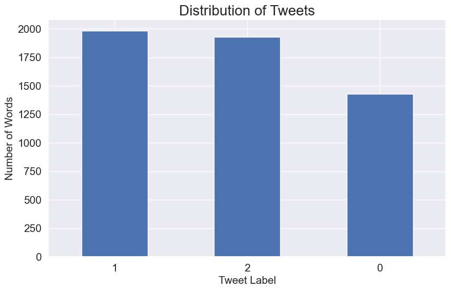

```python
## Examine class distribution
sns.set(font_scale=1.2)

# Visualize class distribution
df['company'] = pd.factorize(df.company, sort=True)[0]

fig, ax1 = plt.subplots(ncols=1, figsize=(10,6))

df['company'].value_counts().plot(kind='bar',
                            rot=0,
                            fontsize=15,
                            ax=ax1)
ax1.set_title('Distribution of Tweets', fontsize=20)
ax1.set_xlabel('Tweet Label', fontsize=15)
ax1.set_ylabel('Number of Words', fontsize=15)

# save picture
fig1 = ax1.get_figure()
fig1.savefig("../501-project-website/images/SVM_tweet_labels_distribution.png")
```

## Baseline Model

```python
## Baseline model
import random
from collections import Counter
from sklearn.metrics import accuracy_score
from sklearn.metrics import precision_recall_fscore_support

def generate_label_data(class_labels, weights,N=10000):
    y=random.choices(class_labels, weights = weights, k = N)
    print("-----GENERATING DATA-----")
    print("unique entries:",Counter(y).keys())
    print("count of labels:",Counter(y).values()) # counts the elements' frequency
    print("probability of labels:",np.fromiter(Counter(y).values(), dtype=float)/len(y)) # counts the elements' frequency
    return y

## Generate random classifier
def random_classifier(y_data):
    ypred=[];
    max_label=np.max(y_data); #print(max_label)
    for i in range(0,len(y_data)):
        ypred.append(int(np.floor((max_label+1)*np.random.uniform(0,1))))

    print("-----RANDOM CLASSIFIER-----")
    print("count of prediction:",Counter(ypred).values()) # counts the elements' frequency
    print("probability of prediction:",np.fromiter(Counter(ypred).values(), dtype=float)/len(y_data)) # counts the elements' frequency
    print("accuracy",accuracy_score(y_data, ypred))
    print("percision, recall, fscore,",precision_recall_fscore_support(y_data, ypred))

# Random classifier
print("\MULTI-CLASS: UNIFORM LOAD")
y=generate_label_data([0,1,2],[1/3, 1/3, 1/3],10000)
random_classifier(y)
```

```
\MULTI-CLASS: UNIFORM LOAD
-----GENERATING DATA-----
unique entries: dict_keys([2, 1, 0])
count of labels: dict_values([3357, 3340, 3303])
probability of labels: [0.3357 0.334  0.3303]
-----RANDOM CLASSIFIER-----
count of prediction: dict_values([3266, 3380, 3354])
probability of prediction: [0.3266 0.338  0.3354]
accuracy 0.3375
percision, recall, fscore, (array([0.33461538, 0.34292713, 0.33512224]), array([0.34241599, 0.33532934, 0.33482276]), array([0.33847075, 0.33908568, 0.33497243]), array([3303, 3340, 3357]))
```

## Feature selection

Since I am dealing with text data, there are not many features I need to select from. Rows represent one of the three company names that a Tweet mentions, while columns represent a particular word. Preiviously in the data cleaning stage, many words were filtered out in order to end up with the current set of words or features that we have. I filtered out stop words in the English dictionary (such as "I", "an", "the"), hashtags, punctuation, and symbols such as emojis that do not hold significant meaning for the purpose of this analysis. This process helped me select the features that I currently have.

```python
# X
corpus=df["tweets"].to_list()
# Initialize count vectorizer

# Ignore terms that appear in less than 1% of the documents
vectorizer=CountVectorizer(min_df=0.01)

# Run count vectorizer on corpus
Xs  =  vectorizer.fit_transform(corpus)
X=np.array(Xs.todense())

# Convert to one-hot vectors
maxs=np.max(X,axis=0)
X=np.ceil(X/maxs)

# Double check
print(X.shape)
print("DATA POINT-0:",X[0,0:10])
```

```
(5341, 29)
DATA POINT-0: [0. 0. 0. 0. 0. 0. 0. 0. 0. 0.]
```

## Prepare data for SVM

```python
## SET X AND Y

# y: CONVERT FROM STRING LABELS TO INTEGERS
labels=[];
y=[]
for label in df["company"]:
    if label not in labels:
        labels.append(label)
        print("index =",len(labels)-1,": label =",label)
    for i in range(0,len(labels)):
        if(label==labels[i]):
            y.append(i)
y = np.array(y)
y = df['company']

X = X

# Double check
print(X.shape,y.shape)
print("DATA POINT-0:",X[0,0:10],"y =",y[0])
```

```
index = 0 : label = 1
index = 1 : label = 0
index = 2 : label = 2
(5341, 29) (5341,)
DATA POINT-0: [0. 0. 0. 0. 0. 0. 0. 0. 0. 0.] y = 0    1
0    0
0    2
Name: company, dtype: int64
```

```python
# Partion data
X_train, X_test, y_train, y_test = train_test_split(X, y, test_size = 0.2, random_state=4)

# Check
print(X_train.shape)
print(y_train.shape)
print(X_test.shape)
print(y_test.shape)
```

```
(4272, 29)
(4272,)
(1069, 29)
(1069,)
```

## Model Tuning

The C parameter tells the SVM optimization how much to avoid misclassifying each training data point. High values of C give a smaller-margin hyperplane, while a small value of C will cause the optimizer to pick a larger-margin separating hyperplane. The C value essentially dictates the extent to which the model over or under fits. Examining the C values below show that the model is actually "stuck" because the accuracy of the train and test data are the same across various C values. Ideally, there would be different scores for different C paramters, and I will pick the C paramater that gives the highest accuracy, precision, and recall scores. As a result, this warrants further examination as I dig further into the project.

```python
# Tune model with various C values

# Import svc library
from sklearn.svm import SVC

col_headers = ['c_param',
             'accuracy_train',
             'accuracy_test']
all_results = []

C = 500

for i in np.arange(1, 500, 50):
    clf = SVC(C = i, kernel = 'linear')
    clf.fit(X_train, y_train)
    yp_train = clf.predict(X_train)
    yp_test = clf.predict(X_test)

    # append results to dataframe
    results = [i,
              accuracy_score(y_train, yp_train),
              accuracy_score(y_test, yp_test)]
    all_results.append(results)

# create a dataframe
svm_results_df = pd.DataFrame(all_results,
                              columns = col_headers)
svm_results_df.head()
```

|  | c_param | accuracy_train | accuracy_test |
| --- | --- | --- | --- |
| 0 | 1 | 0.671582 | 0.642657 |
| 1 | 51 | 0.671582 | 0.642657 |
| 2 | 101 | 0.671582 | 0.642657 |
| 3 | 151 | 0.671582 | 0.642657 |
| 4 | 201 | 0.671582 | 0.642657 |

## SVM - Final Results

### SVM - Sigmoid Kernel Model and Results

```python
# Initialize model

C=500
mykernel = 'sigmoid'

model = SVC(C=C,kernel=mykernel)

# Fit to training data
model.fit(X_train, y_train)

# Predict on X_train
y_train_pred = model.predict(X_train)
```

```
Training set
Accuracy:  67.15823970037454
Number of mislabeled points:  1403
Test set
Accuracy:  64.26566884939196
Number of mislabeled points:  382
```

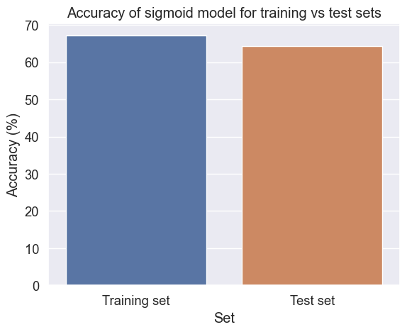

```python
# TEST ACCURACY

# Training set
print("Training set")
print("Accuracy: ", accuracy_score(y_train, y_train_pred) * 100) #accuracy score
print("Number of mislabeled points: ", (y_train != y_train_pred).sum()) #mislabeled points


# Test set
y_test_pred = model.predict(X_test)
print("Test set")
print("Accuracy: ", accuracy_score(y_test, y_test_pred)*100) #accuracy score
print("Number of mislabeled points: ", (y_test != y_test_pred).sum()) #mislabeled points

# Plot
model_accuracies = pd.DataFrame({'Set':['Training set','Test set'], 'Accuracy (%)': [accuracy_score(y_train, y_train_pred) * 100, accuracy_score(y_test, y_test_pred)*100]})
sns.barplot(data=model_accuracies, x="Set", y="Accuracy (%)").set(title = 'Accuracy of '+str(mykernel)+' model for training vs test sets' )
plt.savefig("../501-project-website/images/svm_"+str(mykernel)+"_tweets_accuracy.png")
```

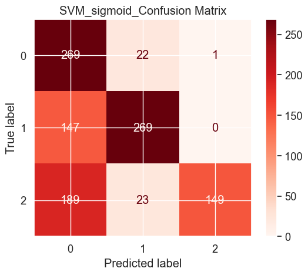

```python
# CONFUSION MATRIX

# Import confusion matrix library
from sklearn.metrics import plot_confusion_matrix

# Create confusion matrix
plot_confusion_matrix(model, X_test , y_test , cmap="Reds")

# Plot confusion matrix
plt.title("SVM_"+str(mykernel)+"_Confusion Matrix")
plt.savefig("../501-project-website/images/SVM_"+str(mykernel)+"_record_confusion_matrix.png")
```

### SVM - Linear Kernel Model and Results

```python
# Initialize model

C=500
mykernel = 'linear'

model = SVC(C=C,kernel=mykernel)

model

# Fit to training data
model.fit(X_train, y_train)

# Predict on X_train
y_train_pred = model.predict(X_train)
```

```
Training set
Accuracy:  67.15823970037454
Number of mislabeled points:  1403
Test set
Accuracy:  64.26566884939196
Number of mislabeled points:  382
```

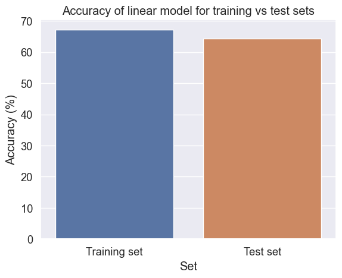

```python
# TEST ACCURACY

# Training set
print("Training set")
print("Accuracy: ", accuracy_score(y_train, y_train_pred) * 100) #accuracy score
print("Number of mislabeled points: ", (y_train != y_train_pred).sum()) #mislabeled points

# Test set
y_test_pred = model.predict(X_test)
print("Test set")
print("Accuracy: ", accuracy_score(y_test, y_test_pred)*100) #accuracy score
print("Number of mislabeled points: ", (y_test != y_test_pred).sum()) #mislabeled points

# Plot
model_accuracies = pd.DataFrame({'Set':['Training set','Test set'], 'Accuracy (%)': [accuracy_score(y_train, y_train_pred) * 100, accuracy_score(y_test, y_test_pred)*100]})
sns.barplot(data=model_accuracies, x="Set", y="Accuracy (%)").set(title = 'Accuracy of '+str(mykernel)+' model for training vs test sets' )
plt.savefig("../501-project-website/images/svm_"+str(mykernel)+"_tweets_accuracy.png")
```

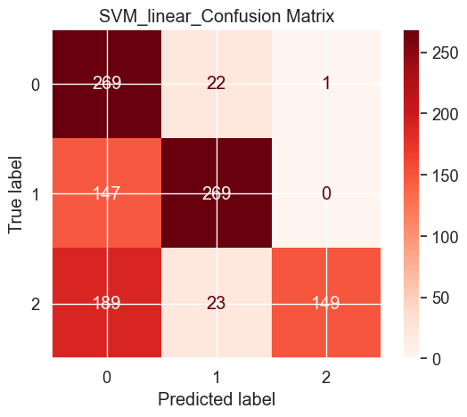

```python
# CONFUSION MATRIX

# Import confusion matrix library
from sklearn.metrics import plot_confusion_matrix

# Create confusion matrix
plot_confusion_matrix(model, X_test , y_test , cmap="Reds")

# Plot confusion matrix
plt.title("SVM_"+str(mykernel)+"_Confusion Matrix")
plt.savefig("../501-project-website/images/SVM_"+str(mykernel)+"_record_confusion_matrix.png")
```

### SVM - RBF Kernel Model and Results

```python
# Initialize model

C=500
mykernel = 'rbf'

model = SVC(C=C,kernel=mykernel)

model

# Fit to training data
model.fit(X_train, y_train)

# Predict on X_train
y_train_pred = model.predict(X_train)
```

```
Training set
Accuracy:  67.15823970037454
Number of mislabeled points:  1403
Test set
Accuracy:  64.92048643592142
Number of mislabeled points:  375
```

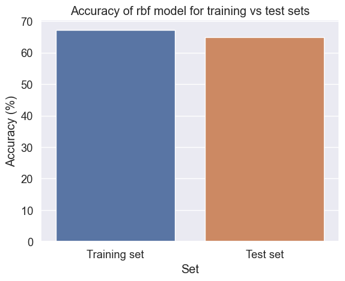

```python
# TEST ACCURACY

# Training set
print("Training set")
print("Accuracy: ", accuracy_score(y_train, y_train_pred) * 100) #accuracy score
print("Number of mislabeled points: ", (y_train != y_train_pred).sum()) #mislabeled points

# Test set
y_test_pred = model.predict(X_test)
print("Test set")
print("Accuracy: ", accuracy_score(y_test, y_test_pred)*100) #accuracy score
print("Number of mislabeled points: ", (y_test != y_test_pred).sum()) #mislabeled points

# Plot
model_accuracies = pd.DataFrame({'Set':['Training set','Test set'], 'Accuracy (%)': [accuracy_score(y_train, y_train_pred) * 100, accuracy_score(y_test, y_test_pred)*100]})
sns.barplot(data=model_accuracies, x="Set", y="Accuracy (%)").set(title = 'Accuracy of '+str(mykernel)+' model for training vs test sets' )
plt.savefig("../501-project-website/images/svm_"+str(mykernel)+"_tweets_accuracy.png")
```

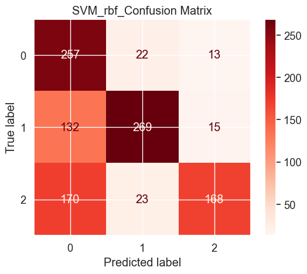

```python
# CONFUSION MATRIX

# Import confusion matrix library
from sklearn.metrics import plot_confusion_matrix

# Create confusion matrix
plot_confusion_matrix(model, X_test , y_test , cmap="Reds")

# Plot confusion matrix
plt.title("SVM_"+str(mykernel)+"_Confusion Matrix")
plt.savefig("../501-project-website/images/SVM_"+str(mykernel)+"_record_confusion_matrix.png")
```

### SVM - Polynomial Kernel Model and Results

```python
# Initialize model

C=500
mykernel = 'poly'

model = SVC(C=C,kernel=mykernel)

model

# Fit to training data
model.fit(X_train, y_train)

# Predict on X_train
y_train_pred = model.predict(X_train)
```

```
Training set
Accuracy:  67.15823970037454
Number of mislabeled points:  1403
Test set
Accuracy:  64.26566884939196
Number of mislabeled points:  382
```

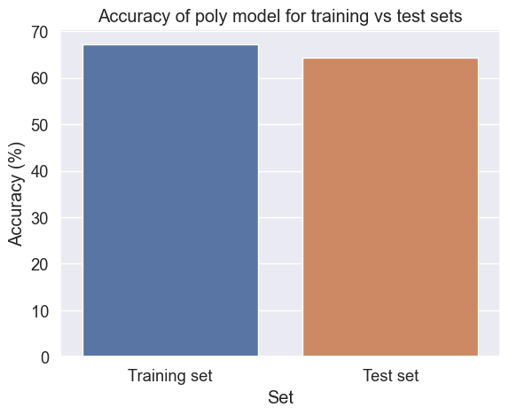

```python
# TEST ACCURACY

# Training set
print("Training set")
print("Accuracy: ", accuracy_score(y_train, y_train_pred) * 100) #accuracy score
print("Number of mislabeled points: ", (y_train != y_train_pred).sum()) #mislabeled points

# Test set
y_test_pred = model.predict(X_test)
print("Test set")
print("Accuracy: ", accuracy_score(y_test, y_test_pred)*100) #accuracy score
print("Number of mislabeled points: ", (y_test != y_test_pred).sum()) #mislabeled points

# Plot
model_accuracies = pd.DataFrame({'Set':['Training set','Test set'], 'Accuracy (%)': [accuracy_score(y_train, y_train_pred) * 100, accuracy_score(y_test, y_test_pred)*100]})
sns.barplot(data=model_accuracies, x="Set", y="Accuracy (%)").set(title = 'Accuracy of '+str(mykernel)+' model for training vs test sets' )
plt.savefig("../501-project-website/images/svm_"+str(mykernel)+"_tweets_accuracy.png")
```

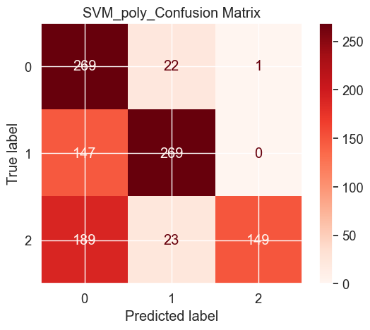

```python
# CONFUSION MATRIX

# Import confusion matrix library
from sklearn.metrics import plot_confusion_matrix

# Create confusion matrix
plot_confusion_matrix(model, X_test , y_test , cmap="Reds")

# Plot confusion matrix
plt.title("SVM_"+str(mykernel)+"_Confusion Matrix")
plt.savefig("../501-project-website/images/SVM_"+str(mykernel)+"_record_confusion_matrix.png")
```

## Conclusions

In conclusion, I think this model is not very accurate in predicting which word comes from which Tweet. The accuracy scores for both training and test sets do not meet the 85% threshold for a model to be considered accurate.

One future direction is to work on considering the context of a word in its label. For example, I hope to include the context of a word's sentence or Tweets in the classification, so that in the Count Vectorizer function, each row represents a Tweet and each column represents a distinct vocabulary. To do this, I need to go back to my data cleaning sections and make sure that the context of a word is included in the cleaned Tweets datasets.